# Data Mining, Classification, Prediction

Andrea Virgen

# Oura Ring Biodata Analysis

### Introduction

This dataset is a collection of health data from one individual measured with an Oura Ring over the course of 221 days. This wearable bio tracker collects a breadth of data: sleep, heart rate, breathing rate, body temperature, and physical activity. Oura software uses this information to calculate scores meant to inform the user of their sleep quality and its influence over other bio metrics. [https://ouraring.com/blog]

My intention is to explore how and if fluctuations in temperature readings can be predicted by lifestyle choices and/or biometrics. Temperature readings are stored as standard deviations in Oura software, so I have categorized data points as either Increase or Decrease dependent on their orientation to the mean: there are 73 observations above and 103 observations below.

```r
library(tidyverse)
library(readr)
library(readxl)

biotrends <- read_csv("/Users/andi/Desktop/PORTFOLIO/Project2/oura_2020-12-05_2021-12-05_trends.csv")

#remove scores, NA values, and days with non-wear time
biotrends %>%
  select(-c(2:9,20:22,28:34,48:56)) %>%
  na.omit() %>%
  filter(`Non-wear Time`== 0) -> biotrends

biotrends %>%
  select(c(4:5,10,14:16,20,28)) -> biotrends

#create binary var
biotrends %>%
  mutate(`Temperature` = ifelse(`Temperature Deviation (°C)`>0, "Increase", "Decrease")) %>%
  select(-5) -> bioanalysis

table(bioanalysis$Temperature)
```

```
##
## Decrease Increase
##      103       73
```

### Cluster Analysis

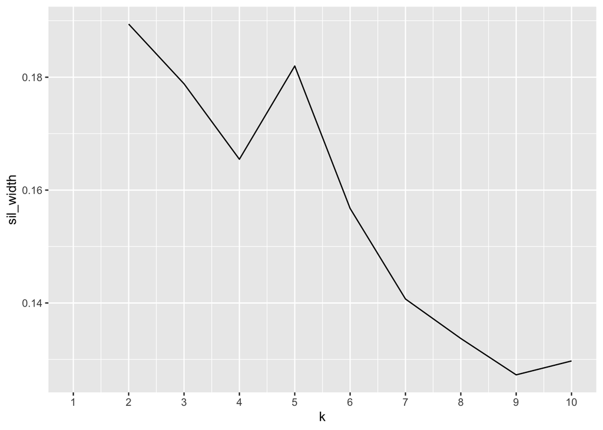

```r
library(cluster)
library(GGally)

# create subset of just numeric variables
bioanalysis %>%
  select_if(is.numeric) -> bio_num
#scale variables
bio_scale <- data.frame(scale(bio_num))

# calculate silhouette width and pick # of clusters
sil_width<-vector()
for(i in 2:10){
  pam_fit <- pam(bio_scale, k = i)
  sil_width[i] <- pam_fit$silinfo$avg.width
}
ggplot()+geom_line(aes(x=1:10,y=sil_width))+scale_x_continuous(name="k",breaks=1:10)
```

```r
# pam w/ 3 clusters
bio_scale %>%
  pam(k=2) -> bio_pam

#results of pam
bio_pam
```

```
## Medoids:
##       ID Awake.Time REM.Sleep.Time Sleep.Latency Average.HRV Respiratory.Rate
## [1,]  65 -0.4691774     -0.4621685   -0.49791539   0.3526651       0.07356281
## [2,] 103  1.0130837      1.2355701    0.09083418  -0.2384688       0.42348319
##           Steps Average.MET
## [1,] -0.1981774 -0.05930791
## [2,]  0.2165191 -0.05930791
## Clustering vector:
##   [1] 1 1 1 1 1 2 1 2 1 1 2 1 1 2 1 2 1 1 1 1 2 1 2 1 1 2 2 1 1 1 1 1 1 2 1 1 1
##  [38] 2 2 1 2 1 1 1 1 1 2 1 1 2 1 1 2 1 1 1 2 1 1 2 2 1 1 1 1 1 1 1 1 1 1 2 1 1
##  [75] 1 1 1 1 1 1 1 2 1 1 1 1 1 1 1 1 2 1 1 2 2 1 1 1 2 1
##  [ reached getOption("max.print") -- omitted 76 entries ]
## Objective function:
##    build     swap
## 2.295102 2.295102
##
## Available components:
##  [1] "medoids"    "id.med"     "clustering" "objective"  "isolation"
##  [6] "clusinfo"   "silinfo"    "diss"       "call"       "data"
```

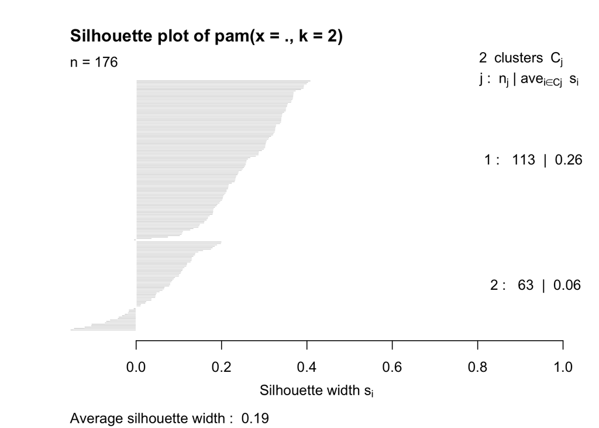

```r
plot(bio_pam,which=2)
```

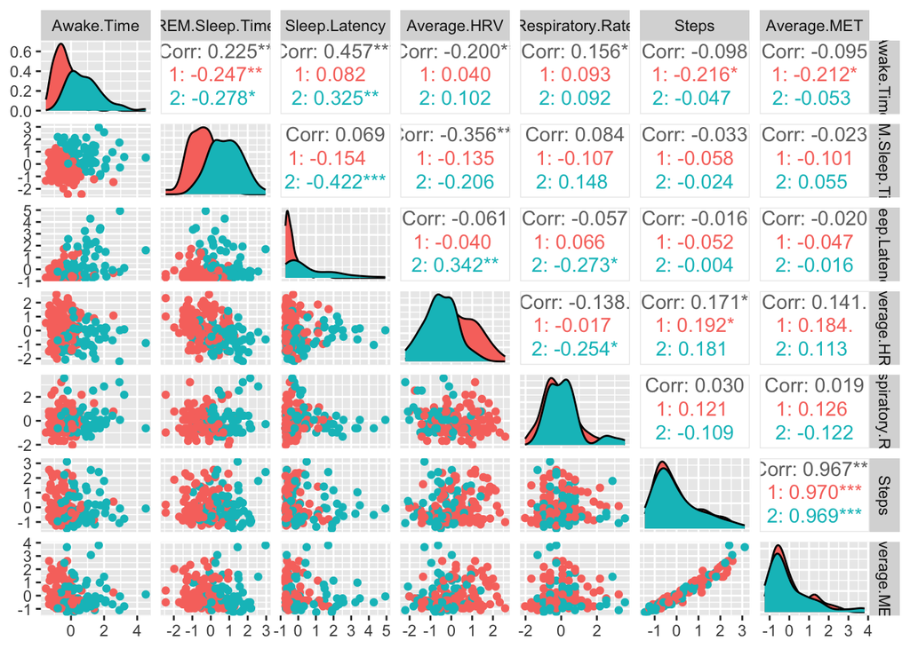

```r
# visualize clusters in ggpairs
bio_scale %>%
  mutate(cluster=as.factor(bio_pam$clustering)) %>%
  ggpairs(columns = c(1:7), aes(color=cluster))
```

There were a few unexpected correlations: Average HRV showed a small positive correlation with Sleep Latency in cluster 2, Average MET and Awake Time were slightly negatively correlated in cluster 1, Respiratory Rate and Sleep Latency showed a slight negative correlation in cluster 2, and Respiratory Rate and Average HRV showed another slight negative correlation in cluster 2.

### Dimensionality Reduction with PCA

```r
library(factoextra)
# eig1<- bio %>% cor %>% eigen()
# eig1$vectors

# conduct pca with scaled data
bio_pca <- princomp(bio_scale)
summary(bio_pca, loadings=T)
```

```
## Importance of components:
##                          Comp.1   Comp.2    Comp.3    Comp.4     Comp.5
## Standard deviation     1.445246 1.271621 1.0866106 0.9698580 0.79182769
## Proportion of Variance 0.300096 0.232323 0.1696385 0.1351428 0.09008198
## Cumulative Proportion  0.300096 0.532419 0.7020575 0.8372003 0.92728232
##                            Comp.6      Comp.7
## Standard deviation     0.68850699 0.179135892
## Proportion of Variance 0.06810724 0.004610434
## Cumulative Proportion  0.99538957 1.000000000
##
## Loadings:
##                  Comp.1 Comp.2 Comp.3 Comp.4 Comp.5 Comp.6 Comp.7
## Awake.Time        0.281  0.513  0.317  0.201  0.119  0.709
## REM.Sleep.Time    0.203  0.420 -0.376 -0.440  0.639 -0.198
## Sleep.Latency     0.163  0.410  0.631        -0.140 -0.622
## Average.HRV      -0.307 -0.329  0.426  0.265  0.738
## Respiratory.Rate         0.245 -0.419  0.831        -0.259
## Steps            -0.617  0.331                              0.709
## Average.MET      -0.612  0.338                             -0.705
```

```r
# save eigen values and varience proportion for scree plot
eigval<-bio_pca$sdev^2
varprop=round(eigval/sum(eigval), 2)

# can compare these two and only keep PCs where eigval > 1
# eigval for each PC shows the correlation for each variable across the PC axis
eigval
```

```
##     Comp.1     Comp.2     Comp.3     Comp.4     Comp.5     Comp.6     Comp.7
## 2.08873650 1.61702085 1.18072265 0.94062463 0.62699108 0.47404188 0.03208967
```

```r
varprop
```

```
## Comp.1 Comp.2 Comp.3 Comp.4 Comp.5 Comp.6 Comp.7
##   0.30   0.23   0.17   0.14   0.09   0.07   0.00
```

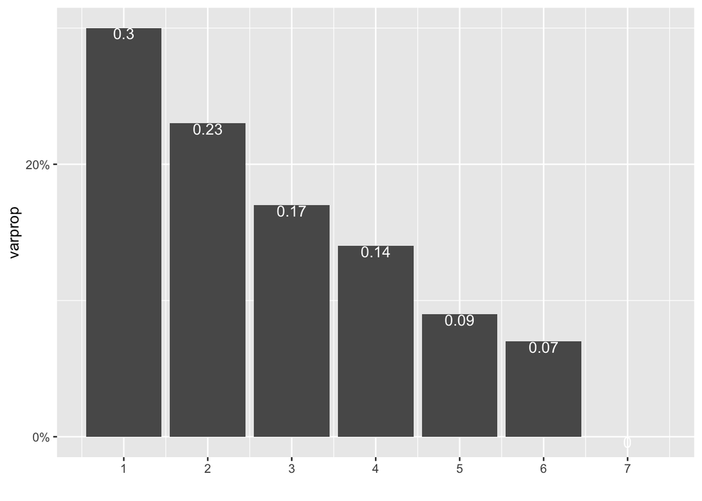

```r
ggplot() + geom_bar(aes(y=varprop, x=1:7), stat="identity") + xlab("") + geom_path() +
  geom_text(aes(x=1:7, y=varprop, label=round(varprop, 2)), vjust=1, col="white")+
  scale_y_continuous(breaks=seq(0, .6, .2), labels = scales::percent) +
  scale_x_continuous(breaks=1:10)
```

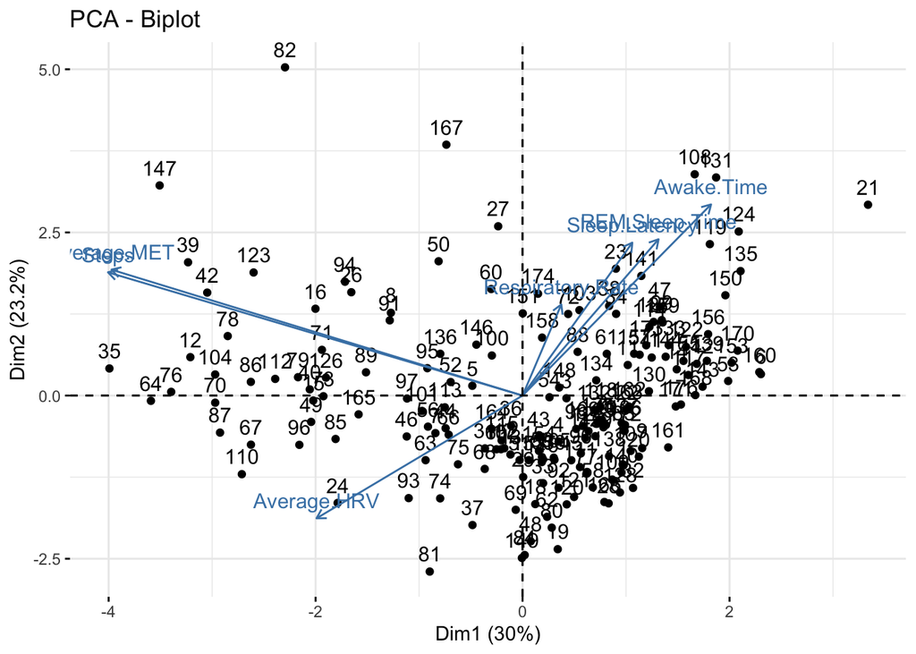

```r
fviz_pca_biplot(bio_pca)
```

PC 1 showed the strongest negative correlations with the variables Steps and Average MET at approximately -.61 each. This PC also showed a negative correlation of -.31 in Average HRV(Heart Rate Variability).

PC2 showed the most positive relationships out of the 3 Principle Components and one negative with Average HRV. Awake Time has the highest positive correlation with PC2 at .51 with REM Sleep Time and Sleep Latency having the second and third largest positive correlations.

PC3 showed the strongest positive correlation in Sleep Latency. Average HRV and Respiratory Rate are inversely correlated across this PC at almost the same rate with Respiratory Rate being the negative counterpart. Awake Time and REM Sleep Time were also inversely correlated across this component.

### Linear Classifier

```r
# may not need this
bioanalysis %>%
  mutate(Temp = ifelse(Temperature == "Increase", 1, 0)) -> bio_glm

# fit linear model to temperature calculated by vars
fit <- glm(Temp ~ `REM Sleep Time` + `Awake Time` + `Sleep Latency` + `Average HRV` + `Respiratory Rate` + `Steps` + `Average MET`, data=bio_glm, family="binomial")

# prediction scores for each Temperature calculated from vars
score <- predict(fit, type="response")

# compute scores for glm
class_diag(score,truth=bio_glm$Temp, positive= 1)
```

```
##           acc  sens  spec    ppv     f1    ba    auc
## Metrics 0.733 0.589 0.835 0.7167 0.6466 0.712 0.7811
```

```r
# confusion matrix
# increases are more likely to be predicted by this model
table(truth = bioanalysis$Temperature, prediction = score>.5)
```

```
##           prediction
## truth      FALSE TRUE
##   Decrease    86   17
##   Increase    30   43
```

```r
# cross-validation of linear classifier here w/ folds
k=10 #choose number of folds
data<-bio_glm[sample(nrow(bio_glm)),] #randomly order rows
folds<-cut(seq(1:nrow(bio_glm)),breaks=k,labels=F) #create 10 folds
diags<-NULL
for(i in 1:k){
  ## Create training and test sets
  train<-data[folds!=i,]
  test<-data[folds==i,]
  truth<-test$Temp
  ## Train model on training set
  fit<-glm(Temp~(.)^2,data=train,family="binomial")
  probs<-predict(fit,newdata = test,type="response")
  ## Test model on test set (save all k results)
  diags<-rbind(diags,class_diag(probs,truth, positive=1))
}

summarize_all(diags,mean)
```

```
##   acc sens spec ppv f1 ba auc
## 1   1    1    1   1  1  1   1
```

### Non-Parametric Classifier

```r
library(caret)
library(rpart)
library(rpart.plot)

fit <- rpart(Temperature~., data=bioanalysis)
fit
```

```
## n= 176
##
## node), split, n, loss, yval, (yprob)
##       * denotes terminal node
##
##  1) root 176 73 Decrease (0.5852273 0.4147727)
##    2) Awake Time< 8265 141 45 Decrease (0.6808511 0.3191489)
##      4) Average HRV>=47.5 111 26 Decrease (0.7657658 0.2342342)
##        8) Sleep Latency< 1095 94 16 Decrease (0.8297872 0.1702128) *
##        9) Sleep Latency>=1095 17  7 Increase (0.4117647 0.5882353) *
##      5) Average HRV< 47.5 30 11 Increase (0.3666667 0.6333333)
##       10) Sleep Latency>=1140 9  3 Decrease (0.6666667 0.3333333) *
##       11) Sleep Latency< 1140 21  5 Increase (0.2380952 0.7619048) *
##    3) Awake Time>=8265 35  7 Increase (0.2000000 0.8000000) *
```

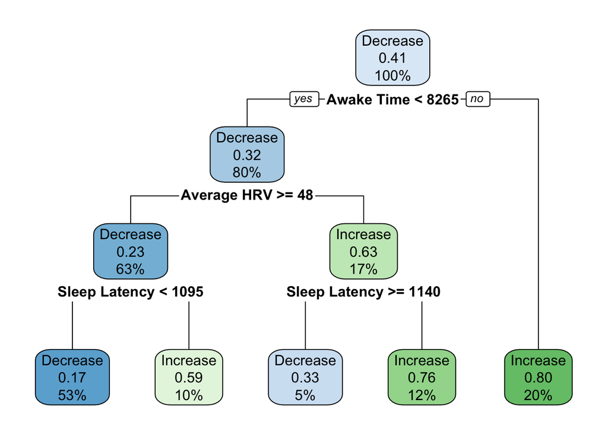

```r
rpart.plot(fit)
```

```r
# cross-validation for tree
# fit <- rpart(Temperature~., data=bioanalysis, trainControl())
# class_diag(fit$pred$Increase, fit$pred$obs, positive="Increase")
```

### Regression/Numeric Prediction

```r
# using linear model to predict the actual Temperature Deviations
fit <- lm(`Temperature Deviation (°C)` ~., data=biotrends)

# predicted temperature deviations
yhat<-predict(fit)

#mean squared error
mean((biotrends$`Temperature Deviation (°C)`-yhat)^2)
```

```
## [1] 0.03937834
```

```r
#cross-validation
k=5 #choose number of folds
data<-biotrends[sample(nrow(biotrends)),] #random order
folds<-cut(seq(1:nrow(biotrends)),breaks=k,labels=F) #folds
diags<-NULL
for(i in 1:k){
  train<-data[folds!=i,]
  test<-data[folds==i,]
  ## Fit linear regression model to training set
  fit<-lm(`Temperature Deviation (°C)` ~.,data=train)
  ## Get predictions/y-hats on test set (fold i)
  yhat<-predict(fit,newdata=test)
  ## Compute prediction error  (MSE) for fold i
  diags<-mean((test$`Temperature Deviation (°C)`-yhat)^2)
}
mean(diags)
```

```
## [1] 0.03732945
```

### Python

```r
# library(reticulate)
#
# # create a new environment
# conda_create("r-reticulate")
#
# # install SciPy
# conda_install("r-reticulate", "pandas")
# # indicate that we want to use a specific condaenv
# use_condaenv("r-reticulate")
#
# # import SciPy (will use "r-reticulate" as per call to use_condaenv)
# pd <- import("pandas")
```

### Concluding Remarks

I would like to conduct a follow-up analysis with a full year’s worth of data to see if the insights change with more data points. Adding another categorical variable that measures self-perceived wellness would be another interesting facet to add and potentially predict. I would hypothesize a self-rated feeling from 1-5 would show an increased likelihood of temperature deviation above the norm, negative correlation with lowered sleep latency, and positive correlation with Average Heart Rate Variability.